# spam_classification

[figure not shown]

## 1. Business Problem Understanding

Move Up

The first step in approaching a data science problem is problem understanding. This step is very important since it allows us to know the kind of decisions we want to make, the information or data that will be needed to inform those decisions and finally, the kind of analysis that will be used to arrive at those decisions. In a nutshell, developing a mental model of the problem allows us to properly structure potentially relevant information needed to solve the problem.

### 1.1 Problem Statement

In today's world, mobile communication through SMS has become a key channel for both personal and business interactions. However, the increasing prevalence of unsolicited messages, or spam, poses a significant challenge to users. These spam messages often include advertisements, promotions, phishing attempts, or fraudulent schemes that can clutter inboxes, waste time, and even compromise security.

The task of distinguishing between legitimate messages (ham) and spam is critical to maintaining the integrity of mobile communication. Traditional rule-based systems often fail to effectively adapt to the evolving nature of spam, making machine learning a powerful tool in this context. A well-trained machine learning model can learn the patterns and features that distinguish spam from ham, improving both accuracy and adaptability.

In this project, we aim to build a spam classification system that can effectively classify SMS messages as either spam or ham. The model will be trained on the SMS Spam Collection dataset from the UCI Machine Learning Repository, which contains raw SMS text data. Our goal is to leverage text processing and machine learning techniques to develop a robust model that can accurately classify unseen SMS messages.

### 1.2 Project Goal

1. Build a spam classification model that accurately classifies SMS messages as spam or ham using machine learning and natural language processing (NLP) techniques.
2. Preprocess the raw text data by performing text cleaning, tokenization, and feature extraction to prepare it for modeling.
3. Deploy the spam classifier as an interactive web application using Streamlit, allowing users to input messages and receive real-time predictions.

### 1.4 Methodology

The methodology that will be used for our project will largely depend on the goals we set out to achieve. The methodlogy framework below gives us a comprehensive guide on the methodology apparoach that will help us achieve our goals.

Methodology Framework

[figure not shown]

Once we have the data, we would need to engineer features based on the data that we obtain, and build a model suitable for binary classification (e.g., Logistic Regression, Decision Tree, Random Forest, Gradient Boosted Machines to name a few), picking the most appropriate model based on the tradeoff between the complexity, the understanding, and the error margin. We will go through the following steps for this project

1. **Data Collection:** Load the SMS Spam Collection dataset for analysis.
2. **Exploratory Data Analysis (EDA):** Perform basic analysis to understand the dataset, including class distribution and message length.
3. **Text Preprocessing:** Clean and prepare the text data through tokenization, normalization, and stemming/lemmatization.
4. **Feature Extraction:** Use techniques like Bag of Words and TF-IDF to convert text into numerical features.
5. **Model Training:** Train machine learning models such as Naive Bayes and Logistic Regression for spam classification.

## 2. Data Collection and Preparation

Move Up

An understanding of the data coupled with problem understanding will help us in cleaning and preparing our data for analysis. It is usually rare to acquire a ready-to-use data for any analysis without some level of preparation. To prepare our data, we normally assess the quality of the data, cleanse, format, blend and sample the data since we may encounter various issues with columns in our data. These issues may include:

- **`Missing values:`** meaning column values are incomplete
- **`Incorrect data:`** meaning you see values not expected for the column name
- **`Inconsistent values:`** meaning some values may fall outside the expected range
- **`Duplicate values:`** meaning whether or not there are duplicate values
- **`Inconsistent data type:`** meaning values entered in the columns may not be consistent with the column names

To properly prepare our data for analysis, we will perform two important tasks which are;

- Part I: Data Quality Assessment
- Part II: Data Cleaning and Preprocessing

### 2.1 Data Quality Assessment

The first task that we will perform under the data collection and preparation step is initial assessment of the quality of data which will easily allow us to properly clean our data. We will use this section to write any code necesary for inspecting the dataset. Once completed, we will leave our report in the Data Quality Report Document.

At the end of our inspection, we will provide a summary of all of our findings.

```python
import pandas as pd
import numpy as np
import matplotlib.pyplot as plt
import seaborn as sns
import warnings
import re
import nltk

from wordcloud import WordCloud
from nltk.corpus import stopwords
from nltk.stem import PorterStemmer
from sklearn.feature_extraction.text import TfidfVectorizer

from sklearn.pipeline import Pipeline
from sklearn.ensemble import RandomForestClassifier
from sklearn.linear_model import LogisticRegression
from sklearn.naive_bayes import MultinomialNB
from sklearn.model_selection import RandomizedSearchCV, GridSearchCV, train_test_split
from sklearn.preprocessing import FunctionTransformer

from yellowbrick.classifier import ClassificationReport, ConfusionMatrix, ROCAUC, PrecisionRecallCurve, ClassPredictionError
from yellowbrick.model_selection import LearningCurve

nltk.download('stopwords')
nltk.download('punkt')
nltk.download('punkt_tab')

warnings.filterwarnings('ignore')
sns.set(color_codes=True)
sns.set(style="whitegrid")
%matplotlib inline
```

Lets load the sms dataset.

```python
sms_data = pd.read_table("../data/raw_data/SMSSpamCollection", sep='\t', header=None, names=['label', 'message'])
```

```python
sms_data.head()
```

|  | label | message |
| --- | --- | --- |
| 0 | ham | Go until jurong point, crazy.. Available only ... |
| 1 | ham | Ok lar... Joking wif u oni... |
| 2 | spam | Free entry in 2 a wkly comp to win FA Cup fina... |
| 3 | ham | U dun say so early hor... U c already then say... |
| 4 | ham | Nah I don't think he goes to usf, he lives aro... |

```python
sms_data.shape
```

```
(5572, 2)
```

> We can see from the above results that we have `5572` observations and just `2` columns. We will proceed to assess the quality of the data and make the necessary cleaning before setting out to achieve our goals.

In this step we will be assessing the quality of the data and make all the possible recommendation for cleaning this data.

```python
# Checking data specific information

sms_data.info()
```

```
<class 'pandas.core.frame.DataFrame'>
RangeIndex: 5572 entries, 0 to 5571
Data columns (total 2 columns):
 #   Column   Non-Null Count  Dtype
---  ------   --------------  -----
 0   label    5572 non-null   object
 1   message  5572 non-null   object
dtypes: object(2)
memory usage: 87.2+ KB
```

```python
# Checking summary statistics about the data

sms_data.describe(include="all")
```

|  | label | message |
| --- | --- | --- |
| count | 5572 | 5572 |
| unique | 2 | 5169 |
| top | ham | Sorry, I'll call later |
| freq | 4825 | 30 |

```python
# Inspect message that appears most in the data

sms_data[sms_data["message"] == "Sorry, I'll call later"].head()
```

|  | label | message |
| --- | --- | --- |
| 80 | ham | Sorry, I'll call later |
| 223 | ham | Sorry, I'll call later |
| 339 | ham | Sorry, I'll call later |
| 444 | ham | Sorry, I'll call later |
| 702 | ham | Sorry, I'll call later |

```python
# Checking for duplicates

sms_data[sms_data.duplicated(keep="first")]
```

|  | label | message |
| --- | --- | --- |
| 103 | ham | As per your request 'Melle Melle (Oru Minnamin... |
| 154 | ham | As per your request 'Melle Melle (Oru Minnamin... |
| 207 | ham | As I entered my cabin my PA said, '' Happy B'd... |
| 223 | ham | Sorry, I'll call later |
| 326 | ham | No calls..messages..missed calls |
| ... | ... | ... |
| 5524 | spam | You are awarded a SiPix Digital Camera! call 0... |
| 5535 | ham | I know you are thinkin malaria. But relax, chi... |
| 5539 | ham | Just sleeping..and surfing |
| 5553 | ham | Hahaha..use your brain dear |
| 5558 | ham | Sorry, I'll call later |

403 rows × 2 columns

We will proceed by checking if the data contain any missing values. We can easily tell from the results of the info that there are no missing values but we want to be extremely sure there are no missing values

```python
# Determine the percentage of missing values in our data

def missing_values(data: pd.Dataframe) -> pd.DataFrame:
    """
    Function that checks for null values and computes the percentage of null values

    Parameters:
        data (pd.DataFrame): data whose missing value is to be determined

    Returns:
        missing_output (pd.DataFrame): dataframe of total null values with corresponding percentages
    """
    total = data.isnull().sum().sort_values(ascending=False)
    percentage = round((total / data.shape[0]) * 100, 2)

    missing_output = pd.concat([total, percentage], axis=1, keys=['Total','Percentage'])

    return missing_output
```

```python
# Call the missing values function on data1

miss_values = missing_values(sms_data)
miss_values
```

|  | Total | Percentage |
| --- | --- | --- |
| label | 0 | 0.0 |
| message | 0 | 0.0 |

#### Data Quality Summary:

Base on the ouputs displayed above, here is the summary of the data quality assessment report:

- The dataset consists of two columns, both containing text data types, which are aligned with expectations.
- No missing values were detected, confirming the dataset is complete and no entries are missing.
- Duplicate records were found in the dataset. However, they are acceptable and expected for this analysis.
- The `label` column is imbalanced, with a higher volume of ham (non-spam) messages compared to spam. This imbalance might need addressing during the modeling phase (e.g., through resampling or weighted adjustments).
- The most frequently occurring message in the dataset is: "Sorry, I'll call later".

Even though no high-level data issues were identified, we still need to process the message column for:

- `Text normalization:` Lowercasing, removing special characters, stopwords, and punctuations to standardize the data.
- `Tokenization:` Splitting messages into individual words or tokens to analyze word frequency and patterns.
- `Stemming/Lemmatization:` Reducing words to their root form to improve model consistency.
- `Vectorization:` Converting text data into numerical features using techniques like TF-IDF or Bag of Words for use in machine learning models.

These preprocessing steps are critical to ensure that the messages are appropriately formatted and standardized for model training and performance.

### 2.2 Data Cleaning and Preprocessing

Based on the data quality assessment, there are no major issues that require extensive data cleaning. The dataset contains the expected text data types, has no missing values, and includes acceptable duplicates. However, the message column will require text preprocessing to prepare the data for analysis. This preprocessing will involve steps such as `text normalization`, `tokenization`, and `vectorization`, which will be handled in the next step: **Text Processing**. These actions are necessary to ensure that the text data is in a suitable format for machine learning models.

## 3. Exploratory Data Analysis

Move Up

In this step, we will conduct EDA to understand the structure and characteristics of the SMS Spam Collection dataset. The goal is to extract insights and identify patterns in the data that will guide the preprocessing and modeling stages.

Key Steps in EDA:

- We will examine how many messages are classified as spam versus ham to understand the balance of the dataset.
- Analyze the length of messages (number of words or characters) to identify any trends or differences between spam and ham messages.
- Identify the most common words in both spam and ham messages using word clouds and frequency counts to gain insights into the vocabulary used in each category.
- Generate visualizations such as histograms, bar charts, and word clouds to better understand the data.

##### Class Distribution

Let’s start with the class distribution and a few other insights from the dataset

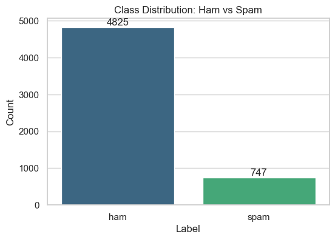

```python
# Plot class distribution

plt.figure(figsize=(6, 4))
ax = sns.countplot(x='label', data=sms_data, palette='viridis')
plt.title("Class Distribution: Ham vs Spam")
plt.xlabel("Label")
plt.ylabel("Count")

# Add count labels
for container in ax.containers:
    ax.bar_label(container)

plt.show()
```

> The bar chart shows the distribution of ham and spam messages. In this dataset, the number of ham messages is more than 4 times the number of spam messages. This is a huge class imbalance and will be explored further in the analysis

##### Message Length Distribution

```python
# Message length distribution (in terms of number of characters)

sms_data['message_length'] = sms_data['message'].apply(len)
```

```python
# Show longest and shortest messages

sms_data.sort_values(by="message_length", ascending=False).head()
```

|  | label | message | message_length |
| --- | --- | --- | --- |
| 1085 | ham | For me the love should start with attraction.i... | 910 |
| 1863 | ham | The last thing i ever wanted to do was hurt yo... | 790 |
| 2434 | ham | Indians r poor but India is not a poor country... | 629 |
| 1579 | ham | How to Make a girl Happy? It's not at all diff... | 611 |
| 2158 | ham | Sad story of a Man - Last week was my b'day. M... | 588 |

```python
# Show longest and shortest messages

sms_data.sort_values(by="message_length", ascending=False).tail()
```

|  | label | message | message_length |
| --- | --- | --- | --- |
| 3376 | ham | :) | 3 |
| 5357 | ham | Ok | 2 |
| 4498 | ham | Ok | 2 |
| 1925 | ham | Ok | 2 |
| 3051 | ham | Ok | 2 |

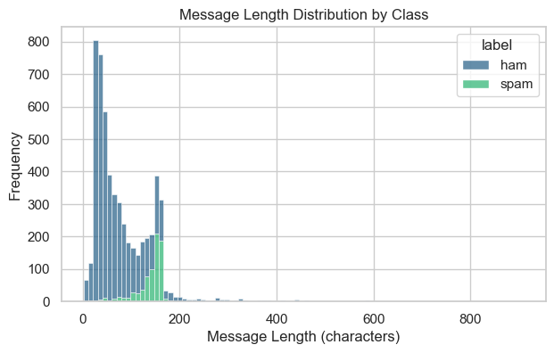

```python
# Plot message length distribution

plt.figure(figsize=(7, 4))
sns.histplot(sms_data, x='message_length', hue='label', multiple='stack', palette='viridis')
plt.title("Message Length Distribution by Class")
plt.xlabel("Message Length (characters)")
plt.ylabel("Frequency")

plt.show()
```

> The histogram shows the distribution of message lengths by class. We can see that spam messages tend to be longer than ham messages.

##### Word Frequency

```python
# Separate the spam and ham messages

spam_messages = sms_data[sms_data['label'] == 'spam']['message']
ham_messages = sms_data[sms_data['label'] == 'ham']['message']
```

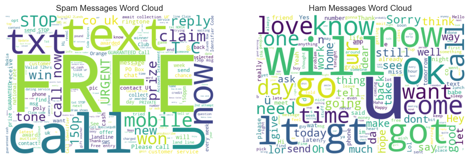

```python
# Generate word clouds for spam and ham messages

spam_wordcloud = WordCloud(width=600, height=400, background_color='white').generate(' '.join(spam_messages))
ham_wordcloud = WordCloud(width=600, height=400, background_color='white').generate(' '.join(ham_messages))

plt.figure(figsize=(12, 6))

# Spam word cloud
plt.subplot(1, 2, 1)
plt.imshow(spam_wordcloud, interpolation='bilinear')
plt.axis('off')
plt.title("Spam Messages Word Cloud")

# Ham word cloud
plt.subplot(1, 2, 2)
plt.imshow(ham_wordcloud, interpolation='bilinear')
plt.axis('off')
plt.title("Ham Messages Word Cloud")

plt.show()
```

## 4. Text Processing

Move Up

Text processing is a crucial step in transforming raw text data into a clean and structured format that can be used for model training. The following steps will be performed in this phase:

Key Steps in Text Processing:

- Convert all text to lowercase to ensure uniformity (e.g., "FREE" and "free" should be treated the same).
- Remove unnecessary punctuation, numbers, and special characters from the messages.
- Split the text into individual words (tokens).
- Remove common words that do not contribute much meaning ("the", "and", "is").
- Reduce words to their root form (e.g., "running" -> "run").

After these steps, we will have a cleaned and tokenized dataset ready for feature extraction.

```python
# Initialize stop words and stemmer

stop_words = set(stopwords.words('english'))
ps = PorterStemmer()
```

```python
def preprocess_text(text: str) -> str:
    """
    Preprocess a single text message (lowercase, remove punctuation, tokenize, remove stop words, and stem).

    Parameters:
        text (str): Raw text message to preprocess.

    Returns:
        str: Preprocessed text message.
    """
    # Lowercase and remove punctuation
    text = text.lower()
    text = re.sub(r'\W', ' ', text)

    # Tokenize sentence
    tokens = nltk.word_tokenize(text)

    # Remove stop words and apply stemming
    tokens = [ps.stem(word) for word in tokens if word not in stop_words]

    # Join tokens back into a single string
    return ' '.join(tokens)
```

```python
# Remove message length as we don't need it for now

sms_data.drop(columns=["message_length"], inplace=True)
```

```python
# Apply preprocessing logic

sms_data["cleaned_message"] = sms_data["message"].apply(preprocess_text)
```

```python
# Show the original and cleaned messages

sms_data[['message', 'cleaned_message']].head()
```

|  | message | cleaned_message |
| --- | --- | --- |
| 0 | Go until jurong point, crazy.. Available only ... | go jurong point crazi avail bugi n great world... |
| 1 | Ok lar... Joking wif u oni... | ok lar joke wif u oni |
| 2 | Free entry in 2 a wkly comp to win FA Cup fina... | free entri 2 wkli comp win fa cup final tkt 21... |
| 3 | U dun say so early hor... U c already then say... | u dun say earli hor u c alreadi say |
| 4 | Nah I don't think he goes to usf, he lives aro... | nah think goe usf live around though |

## 5. Feature Extraction

Move Up

In this step, we will transform the cleaned text into numerical features that can be used by machine learning models. There are several common techniques for feature extraction in text data. There are two popular methods which are:

**Bag of Words (BoW)**

The Bag of Words model converts text into a matrix where each row represents a document (in our case, an SMS message), and each column represents a unique word in the corpus. The cell values contain the frequency (or binary presence) of each word in the corresponding document.

| **Advantages** | **Disadvantages** |
| --- | --- |
| Simple and easy to implement. | Doesn't capture word importance across documents. |
| Works well for short, specific texts. | Ignores semantic meaning and word order. |
| Suitable for small datasets. | High-dimensional for large corpora, inefficient. |

**TF-IDF (Term Frequency - Inverse Document Frequency)**

TF-IDF is a weighted representation of the words in the text, reflecting not only the frequency of a word in a specific document but also its importance across all documents in the corpus. It reduces the weight of commonly occurring words that may not provide much discriminative power.

| **Advantages** | **Disadvantages** |
| --- | --- |
| Highlights words important across documents. | More computationally intensive than BoW. |
| Reduces weight of non-informative words. | Ignores word order and relationships. |
| Better at handling larger and more complex datasets. | - |

For this task, we will use the TF-IDF appraoch as we want to focus on words that are more discriminative across the entire dataset (e.g., identifying specific terms that can help classify spam vs. ham).

```python
# Define the verctorizer

vectorizer = TfidfVectorizer()
```

```python
# Apply vectorizer and convert arrays to DataFrame for easy viewing

cleaned_message_vectors = vectorizer.fit_transform(sms_data['cleaned_message'])
transformed_df = pd.DataFrame(cleaned_message_vectors.toarray(), columns=vectorizer.get_feature_names_out())
```

```python
# Display TF-IDF representations

transformed_df.head()
```

|  | 00 | 000 | 000pe | 008704050406 | 0089 | 0121 | 01223585236 | 01223585334 | 0125698789 | 02 | 0207 | 02072069400 | 02073162414 | 02085076972 | 021 | 03 | 04 | 0430 | 05 | 050703 | 0578 | 06 | 07 | 07008009200 | 07046744435 | 07090201529 | 07090298926 | 07099833605 | 07123456789 | … |
| --- | --- | --- | --- | --- | --- | --- | --- | --- | --- | --- | --- | --- | --- | --- | --- | --- | --- | --- | --- | --- | --- | --- | --- | --- | --- | --- | --- | --- | --- | --- |
| 0 | 0.0 | 0.0 | 0.0 | 0.0 | 0.0 | 0.0 | 0.0 | 0.0 | 0.0 | 0.0 | 0.0 | 0.0 | 0.0 | 0.0 | 0.0 | 0.0 | 0.0 | 0.0 | 0.0 | 0.0 | 0.0 | 0.0 | 0.0 | 0.0 | 0.0 | 0.0 | 0.0 | 0.0 | 0.0 | … |
| 1 | 0.0 | 0.0 | 0.0 | 0.0 | 0.0 | 0.0 | 0.0 | 0.0 | 0.0 | 0.0 | 0.0 | 0.0 | 0.0 | 0.0 | 0.0 | 0.0 | 0.0 | 0.0 | 0.0 | 0.0 | 0.0 | 0.0 | 0.0 | 0.0 | 0.0 | 0.0 | 0.0 | 0.0 | 0.0 | … |
| 2 | 0.0 | 0.0 | 0.0 | 0.0 | 0.0 | 0.0 | 0.0 | 0.0 | 0.0 | 0.0 | 0.0 | 0.0 | 0.0 | 0.0 | 0.0 | 0.0 | 0.0 | 0.0 | 0.0 | 0.0 | 0.0 | 0.0 | 0.0 | 0.0 | 0.0 | 0.0 | 0.0 | 0.0 | 0.0 | … |
| 3 | 0.0 | 0.0 | 0.0 | 0.0 | 0.0 | 0.0 | 0.0 | 0.0 | 0.0 | 0.0 | 0.0 | 0.0 | 0.0 | 0.0 | 0.0 | 0.0 | 0.0 | 0.0 | 0.0 | 0.0 | 0.0 | 0.0 | 0.0 | 0.0 | 0.0 | 0.0 | 0.0 | 0.0 | 0.0 | … |
| 4 | 0.0 | 0.0 | 0.0 | 0.0 | 0.0 | 0.0 | 0.0 | 0.0 | 0.0 | 0.0 | 0.0 | 0.0 | 0.0 | 0.0 | 0.0 | 0.0 | 0.0 | 0.0 | 0.0 | 0.0 | 0.0 | 0.0 | 0.0 | 0.0 | 0.0 | 0.0 | 0.0 | 0.0 | 0.0 | … |

5 rows × 7248 columns

The next step is to train machine learning model on the extracted features. To do this we will employ scikit-learn pipelines to chain the individual steps together so we have a complete pipeline for new data.

## 5. Modeling

Move Up

In this step, we will train several machine learning models to classify SMS messages as spam or ham. We will evaluate the performance of different models using metrics like accuracy, precision, recall, and F1-score to determine the best-performing model.

**Steps for Modeling:**

- Train-Test Split: Split the dataset into training and testing sets.
- Model Training: Train each model using the TF-IDF features from the previous step.
- Evaluation: Measure model performance using accuracy, precision, recall, and F1-score.

### 5.1 Splitting Dataset

It is a good idea to use a test hold-out set. This is a sample of the data that we hold back from our analysis and modeling. We use it right at the end of our project to evaluate the performance of our final model. It is a smoke test that we can use to see if we messed up and to give us confidence on models performance on unseen data. We will use 80% of the dataset for modeling and hold back 20% for validation.

```python
# Encode the label column

sms_data['label'] = sms_data.label.map({'ham':0, 'spam':1})
```

```python
# Split data into train and test

X_train, X_test, y_train, y_test = train_test_split(sms_data['message'], sms_data['label'], test_size=0.2, random_state=2024)
```

### 5.2 Algorithm Evaluation

We don't know which algorithms will do well on this dataset. We will use 5-fold cross validation to evaluate the algorithms. We will evaluate the following algorithms using the F1 score as the evaluation metric.

- Random forest classifier
- Multinomial naive bayes
- Logistic regression

Before we begin, we will define our pipeline. That is the series of steps we want to perform before model is trained and saved. In this section we will perform all the necessary preprocessing, apply the vectorizer and then train our model.

```python
# Define a pipeline with a placeholder classifier

pipeline = Pipeline([
    ('preprocess', FunctionTransformer(lambda x: [preprocess_text(text) for text in x], validate=False)),
    ('tfidf', TfidfVectorizer()),
    ('classifier', RandomForestClassifier(random_state=2024))
])
```

Now we will define parameter space for the models which will be used for random search and grid search cv.

```python
# Define the parameter distributions for RandomizedSearchCV (broader search)
param_distributions = [
    {
        'classifier': [RandomForestClassifier(random_state=2024)],
        'classifier__n_estimators': np.arange(50, 200, 50),
        'classifier__max_depth': [10, 20, None],
        'classifier__min_samples_split': np.arange(2, 10),
        'classifier__min_samples_leaf': [1, 2, 4]
    },
    {
        'classifier': [LogisticRegression(random_state=2024)],
        'classifier__C': np.logspace(-3, 3, 7),
        'classifier__solver': ['lbfgs', 'liblinear']
    },
    {
        'classifier': [MultinomialNB()],
        'classifier__alpha': np.linspace(0.1, 1.0, 10)
    }
]
```

```python
# Use RandomizedSearchCV for initial search over a broad range of hyperparameters

random_search = RandomizedSearchCV(pipeline, param_distributions, n_iter=10, cv=5, scoring='f1', random_state=2024, n_jobs=-1)
random_search.fit(X_train, y_train)
```

```
RandomizedSearchCV(cv=5,
                   estimator=Pipeline(steps=[('preprocess',
                                              FunctionTransformer(func=<function <lambda> at 0x17429dc60>)),
                                             ('tfidf', TfidfVectorizer()),
                                             ('classifier',
                                              RandomForestClassifier(random_state=2024))]),
                   n_jobs=-1,
                   param_distributions=[{'classifier': [RandomForestClassifier(random_state=2024)],
                                         'classifier__max_depth': [10, 20,
                                                                   None],
                                         'classifier__m...
                                         'classifier__n_estimators': array([ 50, 100, 150])},
                                        {'classifier': [LogisticRegression(random_state=2024)],
                                         'classifier__C': array([1.e-03, 1.e-02, 1.e-01, 1.e+00, 1.e+01, 1.e+02, 1.e+03]),
                                         'classifier__solver': ['lbfgs',
                                                                'liblinear']},
                                        {'classifier': [MultinomialNB()],
                                         'classifier__alpha': array([0.1, 0.2, 0.3, 0.4, 0.5, 0.6, 0.7, 0.8, 0.9, 1. ])}],
                   random_state=2024, scoring='f1')
```

```python
# Get the best parameters from RandomizedSearchCV

best_params = random_search.best_params_

print(f"Best model from RandomizedSearchCV: {best_params}")
print(f"Best f1 from RandomizedSearchCV: {random_search.best_score_}")
```

```
Best model from RandomizedSearchCV: {'classifier__n_estimators': 150, 'classifier__min_samples_split': 2, 'classifier__min_samples_leaf': 1, 'classifier__max_depth': None, 'classifier': RandomForestClassifier(random_state=2024)}
Best f1 from RandomizedSearchCV: 0.915893824280921
```

Now, based on the best model from RandomizedSearchCV, we can fine-tune with GridSearchCV

```python
if isinstance(best_params['classifier'], RandomForestClassifier):
    param_grid = {
        'classifier__n_estimators': [best_params['classifier__n_estimators'] - 50, best_params['classifier__n_estimators'], best_params['classifier__n_estimators'] + 50],
        'classifier__min_samples_split': [best_params['classifier__min_samples_split'] - 1, best_params['classifier__min_samples_split']],
        'classifier__min_samples_leaf': [best_params['classifier__min_samples_leaf'], best_params['classifier__min_samples_leaf'] + 1]
    }
    if best_params['classifier__max_depth'] is not None:
        param_grid['classifier__max_depth'] = [best_params['classifier__max_depth'], best_params['classifier__max_depth'] + 5]

elif isinstance(best_params['classifier'], LogisticRegression):
    param_grid = {
        'classifier__C': [best_params['classifier__C'] * 0.5, best_params['classifier__C'], best_params['classifier__C'] * 2],
        'classifier__solver': [best_params['classifier__solver']]
    }

elif isinstance(best_params['classifier'], MultinomialNB):
    param_grid = {
        'classifier__alpha': [best_params['classifier__alpha'] - 0.1, best_params['classifier__alpha'], best_params['classifier__alpha'] + 0.1]
    }
```

```python
# Use GridSearchCV for fine-tuning

grid_search = GridSearchCV(random_search.best_estimator_, param_grid, cv=5, scoring='f1', n_jobs=-1)
grid_search.fit(X_train, y_train)
```

```
GridSearchCV(cv=5,
             estimator=Pipeline(steps=[('preprocess',
                                        FunctionTransformer(func=<function <lambda> at 0x17429dc60>)),
                                       ('tfidf', TfidfVectorizer()),
                                       ('classifier',
                                        RandomForestClassifier(n_estimators=150,
                                                               random_state=2024))]),
             n_jobs=-1,
             param_grid={'classifier__min_samples_leaf': [1, 2],
                         'classifier__min_samples_split': [1, 2],
                         'classifier__n_estimators': [100, 150, 200]},
             scoring='f1')
```

```python
# Get the best model from GridSearchCV
trained_model = grid_search.best_estimator_

# Print the best model and accuracy after GridSearchCV
print(f"Best model after GridSearchCV: {grid_search.best_params_}")
print(f"Best f1 after GridSearchCV: {grid_search.best_score_}")
```

```
Best model after GridSearchCV: {'classifier__min_samples_leaf': 1, 'classifier__min_samples_split': 2, 'classifier__n_estimators': 150}
Best f1 after GridSearchCV: 0.915893824280921
```

### 5.3 Model Understanding

In this final step, we will look at how well the model performed on the test data and then understand why the model made those predictions. For this step we will use both `sckit-learn evalutions metrics` as well as `yellowbrick visuals` for detailed understanding.

`Yellowbrick library` is excellent for visualizing various ML tasks including hyperparameter tuning, model evaluation, model performance etc. You can explore more of the library's functionalities [here](https://www.scikit-yb.org/en/latest/)

```python
def evaluation_report(model: object, X_train: np.array, y_train: np.array, X_test: np.array, y_test: np.array, label: list = ["ham", "spam"]) -> None:
    """
    Function to plot various visualizations for a classification model in a 3x3 matrix layout.

    Parameters:
        model (object): The trained classification model.
        X_train (np.array): Training feature set.
        y_train (np.array): Training labels.
        X_test (np.array): Test feature set.
        y_test (np.array): Test labels.
        label (list): List of target class names (default: ['ham', 'spam']).

    Returns:
        None: Plots the visualizations in a 3x3 matrix layout.
    """

    # Create a 3x3 grid for subplots
    fig, axes = plt.subplots(2, 3, figsize=(15, 10))
    plt.tight_layout(pad=4.0)

    # Create visualizations
    visualizers = [
        ClassificationReport(model, classes=label, ax=axes[0, 0]),
        ConfusionMatrix(model, classes=label, ax=axes[0, 1]),
        ROCAUC(model, classes=label, ax=axes[0, 2]),
        PrecisionRecallCurve(model, classes=label, per_class=True, cmap="Set1", ax=axes[1, 0]),
        ClassPredictionError(model, classes=label, ax=axes[1, 1]),
        LearningCurve(model, scoring='f1_weighted', ax=axes[1, 2])
    ]

    # Fit the model and score for each visualizer
    for viz in visualizers:
        viz.fit(X_train, y_train)
        viz.score(X_test, y_test)
        viz.finalize()

    # Show the plot
    plt.show()
```

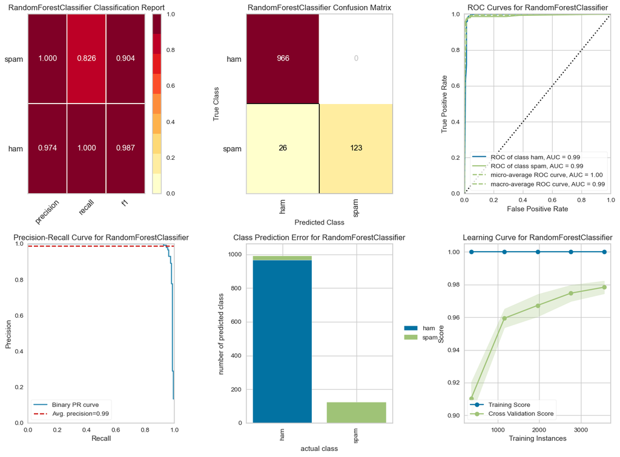

```python
# Plot evaluation reports

evaluation_report(trained_model, X_train, y_train, X_test, y_test)
```

### 5.4 Test Model

To make predictions for a new message using the pipeline we've created, we need to ensure that the message is passed through the same preprocessing and vectorization steps as during training. The pipeline will handle this automatically, so we just need to call the `predict()` method on the pipeline.

Also, we must ensure that our new message is passed as an array (even if it's a single message) since scikit-learn expects input in array-like form.

```python
# Example new email text
new_email = ["Congratulations! You've won a free trip to the Bahamas. Call now to claim your prize!"]

# Use the trained model to predict whether the new email is spam or ham
prediction = trained_model.predict(new_email)

# Interpret the prediction
if prediction[0] == 1:
    print("The email is classified as SPAM.")
else:
    print("The email is classified as HAM.")
```

```
The email is classified as SPAM.
```